# RMarkdown Tutorial

Jill Riddell

2018-11-28

## Introduction and Purpose

The purpose of R Markdown is to generate easily readable and executable reports of code that make it simple and straightforward for others to reproduce your work. R Markdown files (.RMD) can be saved as html files, PDF’s, slideshows, and MS Word documents among others. These formats have different uses depending on the audience.

### Uses of Different File Types

1. html output and .RMd The html output and .RMD file is often most useful when sharing code with other scientists and researchers; it allows others to easily replicate, modify, and/or execute the code. Consider using this format for data reproducibility and accountability. This form can also act as your “digital lab notebook” and be a record of your data manipulation.
2. Word documents and PDF’s These output formats can be most useful for teaching or presenting results. For example, if a scientist working for a consulting form may export their coding results for long-term environmental monitoring data as a PDF because the client only cares about the results, not necessarily the code used to obtain. However, in the case of R workshops and classes, word documents may be more useful as it allows students to take notes more efficiently.

## Opening R Markdown

### Code Chunking

Several options exist for code chunking and it’s output in your final file. Some examples include: eval = FALSE, which prevents the code from being run and is useful for displaying examples; message = FALSE, which does not allow error messages or warnings to appear; echo = FALSE, only allows the results to be printed in the final final; include = FALSE, this runs the code but doesn’t show it in the final output.

## An Example

The following code is to evaluate a statistical model for diel behavior of pH, temperature, and dissolved oxygen at a coal mine drainage stream.

First, install necessary packages and read in the data.

```r
library(car) #install packages
library(devtools)
library(easyGgplot2)
LRM050_1 <- read.csv("LRM_050_1_summer_raw_data.csv") #read in csv
```

Next, a fourier series will be added to the date to give a prediction of each value at time t and add these calculated values to the data frame

```r
pH050 <- lm(pH ~ sin(2*pi*DateTimeFormatExt)+cos(2*pi*DateTimeFormatExt),data=LRM050_1) #calculates a fitted value for pH at time t
pHfitted <- pH050$fitted.values
#creates a vector of the fitted values
LRM050_1$pHfitted <- pHfitted
#adds the vector to the data

Temp050 <- lm(Temp ~ sin(2*pi*DateTimeFormatExt)+cos(2*pi*DateTimeFormatExt),data=LRM050_1)
Tempfitted <- Temp050$fitted.values
LRM050_1$Tempfitted <-Tempfitted

ODO050 <- lm(ODO ~ sin(2*pi*DateTimeFormatExt)+cos(2*pi*DateTimeFormatExt),data=LRM050_1)
ODOfitted <- ODO050$fitted.values
LRM050_1$ODOfitted <- ODOfitted
```

Now, create plots that compare our raw data to our cosine model.

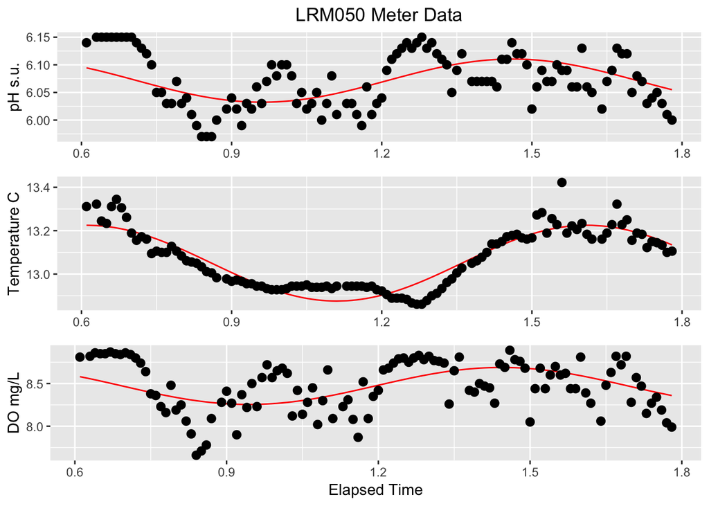

```r
pH050plot <- ggplot(LRM050_1, aes(x=DateTimeFormatExt, y=pHfitted))+
  geom_line(col="red",lwd=0.5)+
  geom_point(aes(y=pH), size=2.5)+
  ggtitle("LRM050 Meter Data")+
  theme(plot.title = element_text(hjust = 0.5))+
  labs(x=NULL, y="pH s.u.")

Temp050plot <- ggplot(LRM050_1, aes(x=DateTimeFormatExt, y=Tempfitted))+
  geom_line(col="red",lwd=0.5)+
  geom_point(aes(y=Temp), size=2.5)+
  labs(x=NULL, y="Temperature C")

ODO050plot <- ggplot(LRM050_1, aes(x=DateTimeFormatExt, y=ODOfitted))+
  geom_line(col="red",lwd=0.5)+
  geom_point(aes(y=ODO), size=2.5)+
  labs(x="Elapsed Time", y= "DO mg/L")

ggplot2.multiplot(pH050plot,Temp050plot,ODO050plot, cols=1)
```

Finally, evaluate the statistical significance of the model to the data. Is this model a good predictor for our data?

```r
summary(pH050)
```

```
##
## Call:
## lm(formula = pH ~ sin(2 * pi * DateTimeFormatExt) + cos(2 * pi *
##     DateTimeFormatExt), data = LRM050_1)
##
## Residuals:
##       Min        1Q    Median        3Q       Max
## -0.089289 -0.036325 -0.008658  0.037541  0.075907
##
## Coefficients:
##                                  Estimate Std. Error  t value Pr(>|t|)
## (Intercept)                      6.071429   0.004018 1511.198  < 2e-16 ***
## sin(2 * pi * DateTimeFormatExt)  0.009500   0.005422    1.752   0.0825 .
## cos(2 * pi * DateTimeFormatExt) -0.037860   0.005899   -6.418  3.6e-09 ***
## ---
## Signif. codes:  0 '***' 0.001 '**' 0.01 '*' 0.05 '.' 0.1 ' ' 1
##
## Residual standard error: 0.04192 on 110 degrees of freedom
## Multiple R-squared:  0.2812, Adjusted R-squared:  0.2681
## F-statistic: 21.52 on 2 and 110 DF,  p-value: 1.297e-08
```

```r
outlierTest(pH050)
```

```
##
## No Studentized residuals with Bonferonni p < 0.05
## Largest |rstudent|:
##     rstudent unadjusted p-value Bonferonni p
## 86 -2.197224           0.030121           NA
```

```r
summary(Temp050)
```

```
##
## Call:
## lm(formula = Temp ~ sin(2 * pi * DateTimeFormatExt) + cos(2 *
##     pi * DateTimeFormatExt), data = LRM050_1)
##
## Residuals:
##      Min       1Q   Median       3Q      Max
## -0.10491 -0.03826 -0.01069  0.03061  0.20590
##
## Coefficients:
##                                  Estimate Std. Error t value Pr(>|t|)
## (Intercept)                     13.050268   0.005157 2530.69   <2e-16 ***
## sin(2 * pi * DateTimeFormatExt) -0.111416   0.006960  -16.01   <2e-16 ***
## cos(2 * pi * DateTimeFormatExt) -0.134487   0.007572  -17.76   <2e-16 ***
## ---
## Signif. codes:  0 '***' 0.001 '**' 0.01 '*' 0.05 '.' 0.1 ' ' 1
##
## Residual standard error: 0.0538 on 110 degrees of freedom
## Multiple R-squared:  0.847,  Adjusted R-squared:  0.8442
## F-statistic: 304.5 on 2 and 110 DF,  p-value: < 2.2e-16
```

```r
outlierTest(Temp050)
```

```
##    rstudent unadjusted p-value Bonferonni p
## 92 4.151142         6.5868e-05    0.0074431
```

```r
summary(ODO050)
```

```
##
## Call:
## lm(formula = ODO ~ sin(2 * pi * DateTimeFormatExt) + cos(2 *
##     pi * DateTimeFormatExt), data = LRM050_1)
##
## Residuals:
##      Min       1Q   Median       3Q      Max
## -0.63944 -0.18784  0.00129  0.21903  0.45940
##
## Coefficients:
##                                 Estimate Std. Error t value Pr(>|t|)
## (Intercept)                      8.47194    0.02533 334.508  < 2e-16 ***
## sin(2 * pi * DateTimeFormatExt)  0.07514    0.03418   2.198     0.03 *
## cos(2 * pi * DateTimeFormatExt) -0.20352    0.03719  -5.473 2.82e-07 ***
## ---
## Signif. codes:  0 '***' 0.001 '**' 0.01 '*' 0.05 '.' 0.1 ' ' 1
##
## Residual standard error: 0.2642 on 110 degrees of freedom
## Multiple R-squared:  0.2331, Adjusted R-squared:  0.2191
## F-statistic: 16.71 on 2 and 110 DF,  p-value: 4.588e-07
```

```r
outlierTest(ODO050)
```

```
##
## No Studentized residuals with Bonferonni p < 0.05
## Largest |rstudent|:
##     rstudent unadjusted p-value Bonferonni p
## 23 -2.508789           0.013586           NA
```